# **Stat 112 - Recitation 11**

> Ozancan Ozdemir - ozancan@metu.edu.tr

## **Data Visualization with Seaborn**

Seaborn is an open source Python library for statistical visualization. It is a tool that uses matplotlib as a foundation, which is meant to be used in conjunction with it, rather than as a replacement. It is designed to work closely with pandas data structures as well as Numpy arrays by allowing the users to quickly create plots from large datasets.

It solves the problem of matplotlib with pandas series and data frame. It is also efficient tool to produce attractive plots with high-level interfaces since it comes with a range of predefined styles and color palettes, which makes it easy to create visually appealing charts with just a few lines of code. Thereby, it is useful tool for Exploratory Data Analysis. (EDA)

Prior to the your analysis, you **have to** import the **seaborn** package with **matplotlib.pyplot**.

```python
import matplotlib.pyplot as plt
import seaborn as sns
```

After that, we also import the other necessary packages for the analysis.

```python
import numpy as np
import pandas as pd
```

Before proceeding, I'd like to show you the general structure of the seaborn functions.

`sns.function_name( df, x = "x", y = "y", arg)`

In this lab, we will try to figure out the properties of the seaborn by considering a famous dataset, mpg.

This dataset contains a subset of the fuel economy data that the EPA makes available on https://fueleconomy.gov/. It contains only models which had a new release every year between 1999 and 2008 - this was used as a proxy for the popularity of the car.

This data is already available in Python, but we import the data since we also would like to practice our pandas skills :)

The description of the variables are given below.

- manufacturer: manufacturer name
- model: model name
- displ: engine displacement, in litres
- year: year of manufacture
- cyl: number of cylinders
- trans: type of transmission
- drv: the type of drive train, where f = front-wheel drive, r = rear wheel drive, 4 = 4wd
- cty: city miles per gallon
- hwy : highway miles per gallon
- fl : fuel type
- class : "type" of car

Import `mpg.xlsx` dataset to your colab enviroment.

```python
mpg = pd.read_excel('mpg.xlsx')
mpg.head()
```

|  | manufacturer | model | displ | year | cyl | trans | drv | cty | hwy | fl | class |
| --- | --- | --- | --- | --- | --- | --- | --- | --- | --- | --- | --- |
| 0 | audi | a4 | 1.8 | 1999 | 4 | auto(l5) | f | 18 | 29 | p | compact |
| 1 | audi | a4 | 1.8 | 1999 | 4 | manual(m5) | f | 21 | 29 | p | compact |
| 2 | audi | a4 | 2.0 | 2008 | 4 | manual(m6) | f | 20 | 31 | p | compact |
| 3 | audi | a4 | 2.0 | 2008 | 4 | auto(av) | f | 21 | 30 | p | compact |
| 4 | audi | a4 | 2.8 | 1999 | 6 | auto(l5) | f | 16 | 26 | p | compact |

```python
mpg.shape
```

```
(234, 11)
```

The dataset contains 234 observations and 11 variables.

```python
mpg.info()
```

```
<class 'pandas.core.frame.DataFrame'>
RangeIndex: 234 entries, 0 to 233
Data columns (total 11 columns):
 #   Column        Non-Null Count  Dtype
---  ------        --------------  -----
 0   manufacturer  234 non-null    object
 1   model         234 non-null    object
 2   displ         234 non-null    float64
 3   year          234 non-null    int64
 4   cyl           234 non-null    int64
 5   trans         234 non-null    object
 6   drv           234 non-null    object
 7   cty           234 non-null    int64
 8   hwy           234 non-null    int64
 9   fl            234 non-null    object
 10  class         234 non-null    object
dtypes: float64(1), int64(4), object(6)
memory usage: 20.2+ KB
```

```python
mpg.isnull().sum().sum() #no missing
```

```
0
```

The data has no missing value.

We explore the package by asking some **research questions**, but the following figure will represent the name of the function and their functionality purposes briefly.

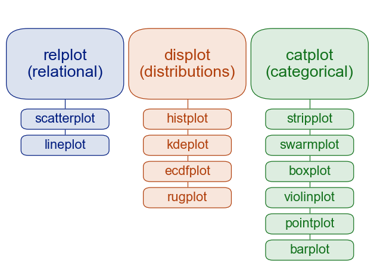

Source : [Seaborn](https://seaborn.pydata.org/)

According to the figure above, we have a general three function in seaborn, and we will determine the plot type by using `kind` operator. However, we can use the functions designed for the specific plot. For example, we can use `catplot` to draw bar plot or `barplot()`.

#### **Univariate Analysis**

In this part, we will explore the variable properties individually.

**RQ1: What is the shape of the distribution of the *highway miles per gallon*(hwy) of the car models?**

The most common approach to visualizing a distribution is the histogram. This is the default approach in `displot()`, which uses the same underlying code as `histplot()`.

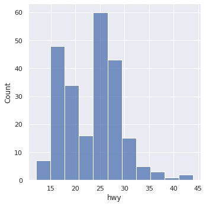

```python
sns.displot(mpg, x = "hwy")
```

Seaborn provides several themes which helps us to improve the apperance of the plot. We can set the style by calling Seaborn's `set()` method.

```python
sns.set()
```

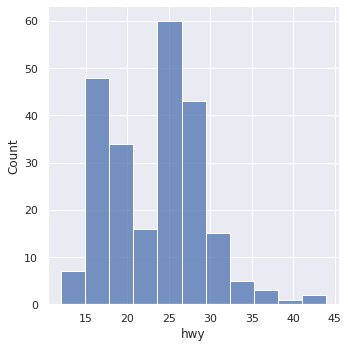

```python
sns.displot(mpg, x = "hwy")
```

We can also set the background through the function `set_style`. Some possible settings are:

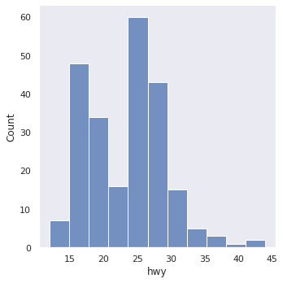

```python
sns.set_style("dark")
sns.displot(mpg, x = "hwy")
```

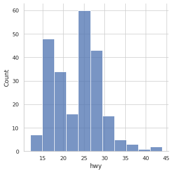

```python
sns.set_style("whitegrid")
sns.displot(mpg, x = "hwy")
```

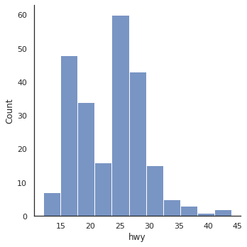

```python
sns.set_style("white")
sns.displot(mpg, x = "hwy")
```

```python
sns.set() # go back to set
```

You can improve your visual by adding title, caption, subtitle and setting axis titles. In doing so, you can use either seaborn function (set, for example) or matplotlib commands.

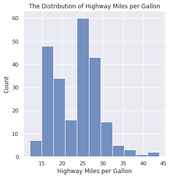

```python
sns.displot(mpg, x = "hwy").set(title = 'The Distribution of Highway Miles per Gallon').set_axis_labels('Highway Miles per Gallon', 'Count')

# .set(title = "") add title name
# .set_axis_labels ("x label", "y label")
```

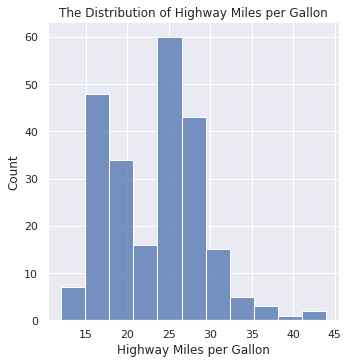

```python
sns.displot(mpg, x = "hwy")
plt.title('The Distribution of Highway Miles per Gallon')
plt.xlabel('Highway Miles per Gallon')
plt.ylabel('Count')
```

The size of the figure is controlled by setting the `height` argument.

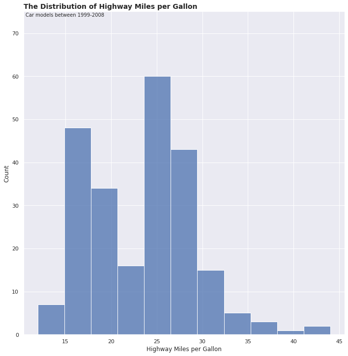

```python
sns.set()
sns.displot(mpg, x = "hwy",height = 10)
plt.title('The Distribution of Highway Miles per Gallon',fontweight="bold",fontsize=14,loc="left") # loc: location
plt.suptitle('Car models between 1999-2008',fontsize=10,x=0.08,y=0.98,ha="left") #ha: horizontal alignment, x and y arranges the position
plt.xlabel('Highway Miles per Gallon' )
plt.ylabel('Count')
plt.ylim(0,75)
plt.show()
```

As in matplotlib, you also can change the figure size in seaborn using `figsize` function. However, `displot` is not working, use `histplot`.

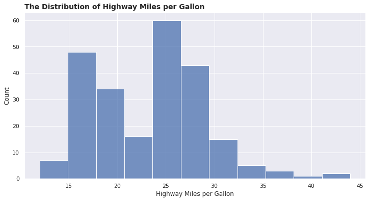

```python
sns.set()
plt.figure(figsize = (12,6))
sns.histplot(mpg, x = "hwy")
plt.title('The Distribution of Highway Miles per Gallon',fontweight="bold",fontsize=14,loc="left") # loc: location
plt.xlabel('Highway Miles per Gallon' )
plt.ylabel('Count')
plt.show()
```

**RQ2: What is the distribution of manufacturer of the car models released between 1999-2008?**

Since the manufacturer is the categorical variable, we can display its distribution by using bar plot. There are two ways of drawing bar plot using seaborn, `catplot` (categorical plot) and `barplot` (bar plot).

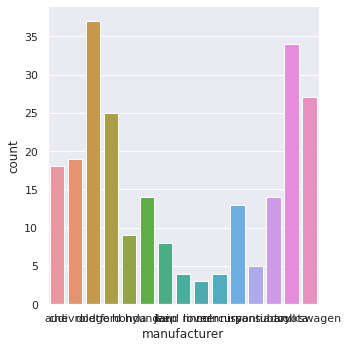

```python
sns.catplot(data=mpg, x="manufacturer", kind="count")
```

Let's make it better..

Order by frequency at first, and then change the color of the plot and rotate the axis.

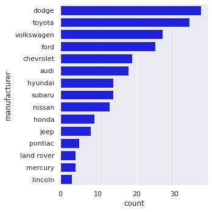

```python
sns.catplot(data=mpg, y="manufacturer",
            kind="count",
            order=mpg.manufacturer.value_counts().index,
            color='blue')

# assing the variable of interest to y, rather than x
# order determines the order of the axis ticks
# color fill the bars
```

You can use a color palette instead of a fixed color. You can see the color palettes from [here](https://seaborn.pydata.org/tutorial/color_palettes.html)

As with the previous example, the size of the figure is controlled by setting the `height`.

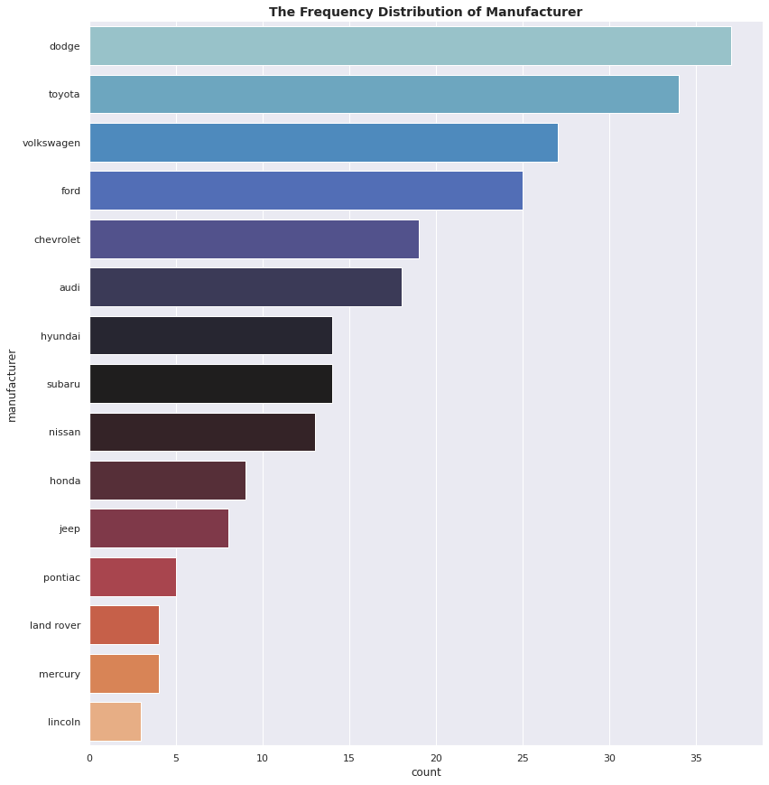

```python
sns.catplot(data=mpg, y="manufacturer",
            kind="count",
            order=mpg.manufacturer.value_counts().index,palette="icefire",
            height = 12)
plt.title('The Frequency Distribution of Manufacturer', fontweight="bold",fontsize=14)
plt.show()
```

You can draw the same plot using `barplot` command. In doing so, you need to extract a frequency table from the raw data.

```python
freq_table = pd.DataFrame(mpg['manufacturer'].value_counts())
freq_table
```

|  | manufacturer |
| --- | --- |
| dodge | 37 |
| toyota | 34 |
| volkswagen | 27 |
| ford | 25 |
| chevrolet | 19 |
| audi | 18 |
| hyundai | 14 |
| subaru | 14 |
| nissan | 13 |
| honda | 9 |
| jeep | 8 |
| pontiac | 5 |
| land rover | 4 |
| mercury | 4 |
| lincoln | 3 |

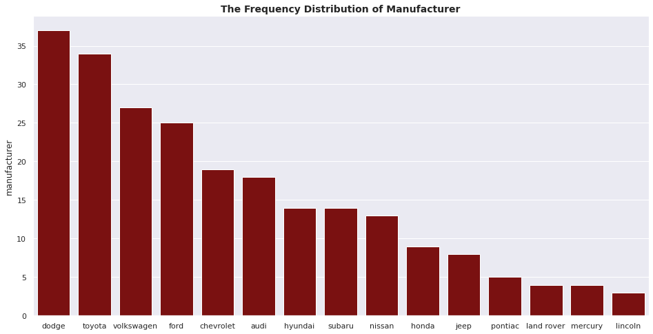

```python
sns.barplot(data = freq_table, x = freq_table.index, y= 'manufacturer', color  = 'darkred' )
plt.title('The Frequency Distribution of Manufacturer', fontweight="bold",fontsize=14)
plt.show()
```

#### **Multivariate Analysis**

In this part, we will draw the plot that includes more than one variables at the same time.

**RQ3: What is the relationship between *displacement* and *highway miles per gallon* of the cars released between 1999 and 2008?**

Now, we will have two numerical variables. The most classical approach here is the **scatter plot**

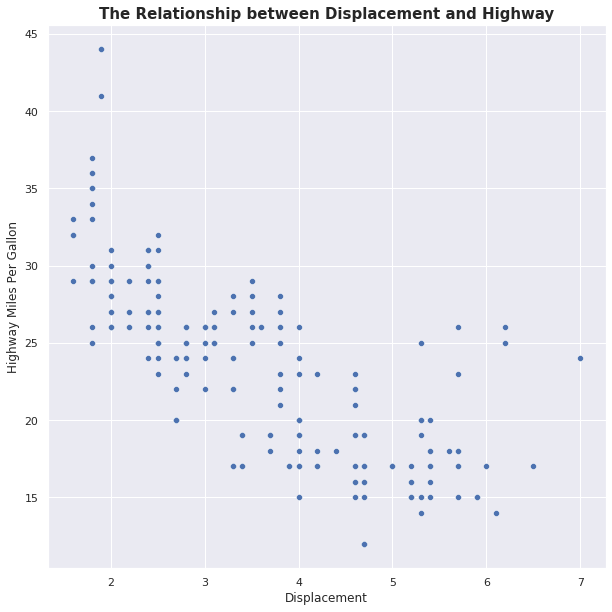

```python
plt.figure(figsize = (10,10)) # set the figure size
sns.scatterplot(data=mpg, x="displ", y="hwy")
plt.title('The Relationship between Displacement and Highway',fontsize = 15, fontweight = "bold")
plt.xlabel('Displacement')
plt.ylabel('Highway Miles Per Gallon')
plt.show()
```

If you would like to draw a scatter plot with the trend line, you should use `lmplot` command.

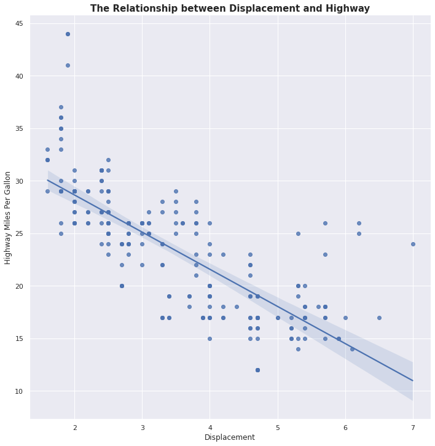

```python
sns.lmplot(data=mpg, x="displ", y="hwy", height = 10)
plt.title('The Relationship between Displacement and Highway',fontsize = 15, fontweight = "bold")
plt.xlabel('Displacement')
plt.ylabel('Highway Miles Per Gallon')
plt.show()
```

**RQ4: What is the relationship between displacement and highway miles per gallon of the cars released by year?**

Now, we will include the third variable to the relationship that we are looking for. In seaborn, we use `hue` argument in the plot to include the third variable.

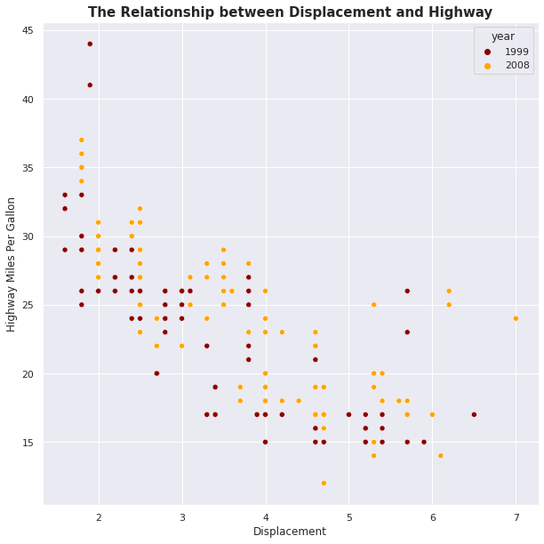

```python
plt.figure(figsize = (10,10)) # set the figure size
sns.scatterplot(data=mpg, x="displ", y="hwy",hue = 'year', palette = ['darkred','orange']) #palette arranges the hue color
plt.title('The Relationship between Displacement and Highway',fontsize = 15, fontweight = "bold")
plt.xlabel('Displacement')
plt.ylabel('Highway Miles Per Gallon')
plt.show()
```

**RQ5: How does *city miles per gallon* by *tranmission* type?**

In this question, we have one categorical and one numerical variable. Thus, we can draw either box plot or violin plot.

Let's draw both!

We use `.boxplot()` function in seaborn to plot the box plot.

[figure not shown]

```python
plt.figure(figsize = (13,13)) # set the figure size
sns.boxplot(data=mpg, x="trans", y="cty") #x: the variable on the x axis, y: the variable on the y axis
plt.title('The Relationship between Transmission and City miles per gallon',fontsize = 15, fontweight = "bold")
plt.xlabel('Transmission')
plt.ylabel('City miles per gallon')
plt.show()
```

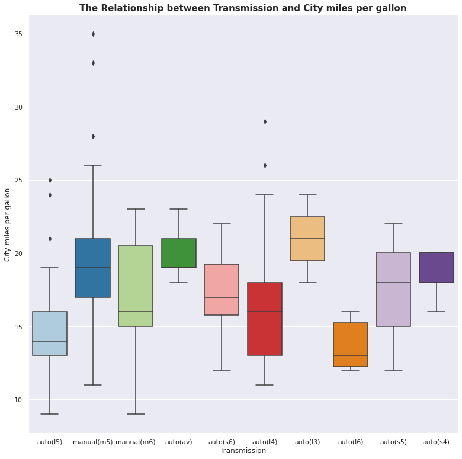

```python
plt.figure(figsize = (13,13)) # set the figure size
sns.boxplot(data=mpg, x="trans", y="cty",
            palette = 'Paired') #x: the variable on the x axis, y: the variable on the y axis, #palette: assign a color palet
plt.title('The Relationship between Transmission and City miles per gallon',fontsize = 15, fontweight = "bold")
plt.xlabel('Transmission')
plt.ylabel('City miles per gallon')
plt.show()
```

If you intend to draw a violin plot, you can use `violinplot` function with the same syntax.

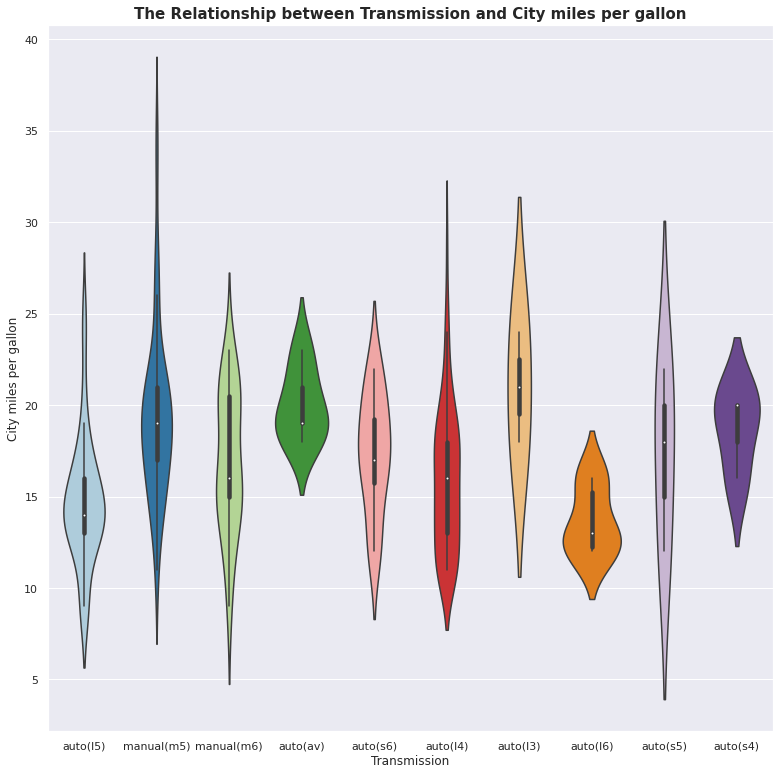

```python
plt.figure(figsize = (13,13)) # set the figure size
sns.violinplot(data=mpg, x="trans", y="cty",
            palette = 'Paired') #x: the variable on the x axis, y: the variable on the y axis, #palette: assign a color palet
plt.title('The Relationship between Transmission and City miles per gallon',fontsize = 15, fontweight = "bold")
plt.xlabel('Transmission')
plt.ylabel('City miles per gallon')
plt.show()
```

**RQ6: How does the highway miles per gallon varies by number of the cylinder in two different years?**

In this research question, we will have three numerical variables. However, two of them can be considered as categorical among these three variables, which are cylinder and year.

Thus, we can construct either box plot or violin plot again. In contrast to the previous example, we have the third variable; year and this can be included to the plot using `hue`argument.

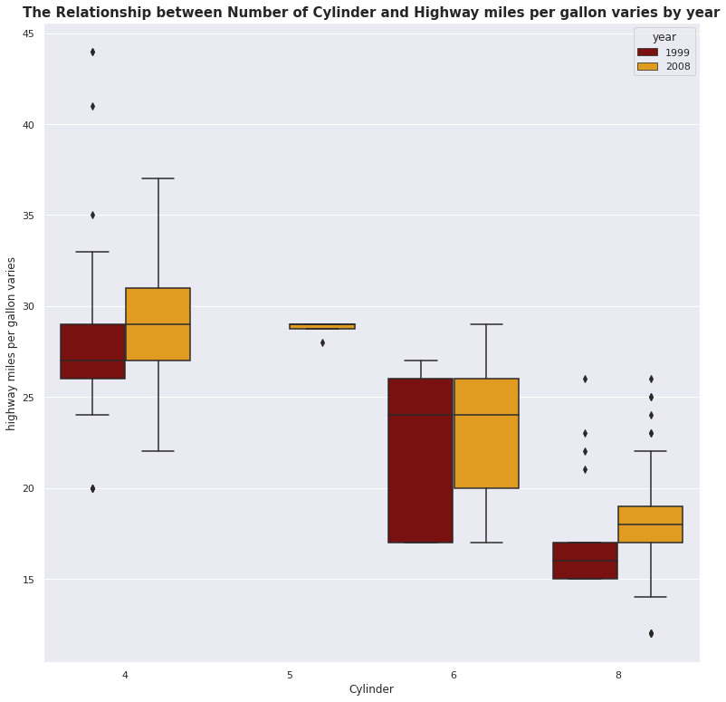

```python
plt.figure(figsize = (13,13)) # set the figure size
sns.boxplot(data=mpg, x="cyl",
            y="hwy",
            hue = 'year',
            palette = ['darkred','orange']) #x: the variable on the x axis, y: the variable on the y axis, #palette: assign a color palet
plt.title('The Relationship between Number of Cylinder and Highway miles per gallon varies by year',fontsize = 15, fontweight = "bold")
plt.xlabel('Cylinder')
plt.ylabel('highway miles per gallon varies')
plt.show()
```

**RQ7: Display the correlation among the numerical variables in the data**

Instead of asking research question, we will show you how to visualize a correlation among the numerical variables in the data. There are several alternatives, for sure and **heatmap** is one of them. You can use `heatmap()` function for this purpose.

In doing so, we will create a correlation matrix at first.

```python
corr_data = mpg.corr() #calculate the correlation table
corr_data
```

|  | displ | year | cyl | cty | hwy |
| --- | --- | --- | --- | --- | --- |
| displ | 1.000000 | 0.147843 | 0.930227 | -0.798524 | -0.766020 |
| year | 0.147843 | 1.000000 | 0.122245 | -0.037232 | 0.002158 |
| cyl | 0.930227 | 0.122245 | 1.000000 | -0.805771 | -0.761912 |
| cty | -0.798524 | -0.037232 | -0.805771 | 1.000000 | 0.955916 |
| hwy | -0.766020 | 0.002158 | -0.761912 | 0.955916 | 1.000000 |

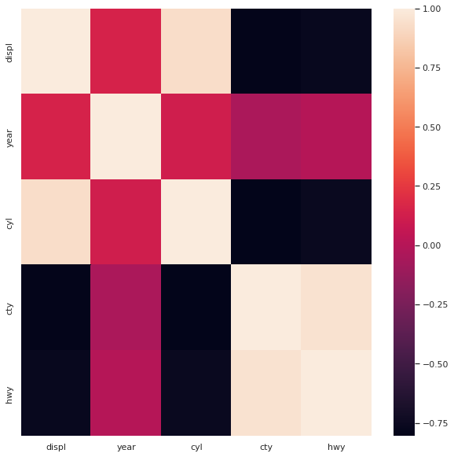

```python
plt.figure(figsize = (10,10)) # set the figure size
sns.heatmap(corr_data)
```

**RQ8: What is the relationship between highway miles and displacement in the levels of drive train (drv)?**

In contrast to coloring the plot by the third variable, we can draw **multiple** plot for each level of the third variable because the detection of the pattern in the plot may be harder when we color our plot by the third variable.

In this case, we will use `FacetGrid`, which creates multi-plot grid for plotting conditional relationships.

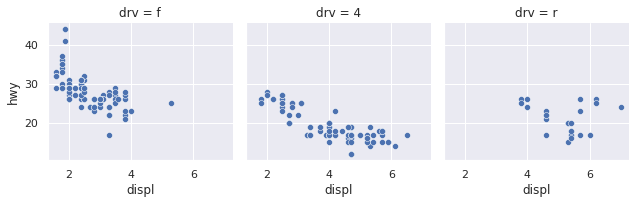

```python
g = sns.FacetGrid(mpg, col="drv")
g.map(sns.scatterplot, "displ", "hwy")
```

The size and shape of the plot is specified at the level of each subplot using the `height` and`aspect`parameters:

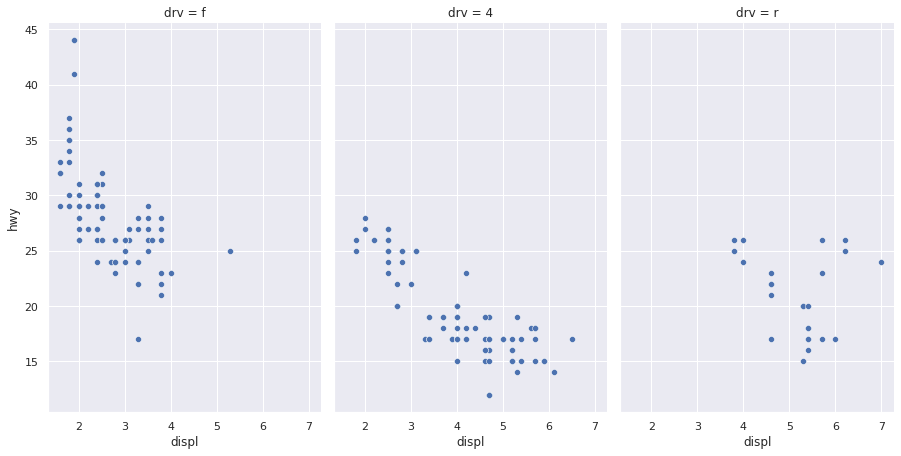

```python
g = sns.FacetGrid(mpg, col="drv", height=6.5, aspect=.65)
g.map(sns.scatterplot, "displ", "hwy")
```

If you intend to add a title to your grid plot, use `fig.subplots_adjust`

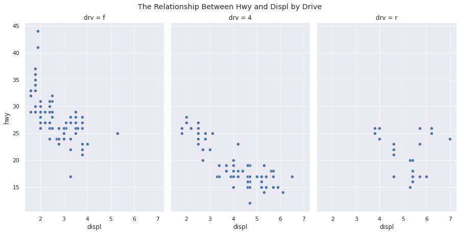

```python
g = sns.FacetGrid(mpg, col="drv", height=6.5, aspect=.65)
g.map(sns.scatterplot, "displ", "hwy")
g.fig.subplots_adjust(top=0.9)
g.fig.suptitle('The Relationship Between Hwy and Displ by Drive')
```

**RQ9: What are the associations between numerical variables in the data? What are the distributions of them?**

As you see, we handle with answering two research questions simultaneously. Note that `scatter_matrix` function `pandas plotting` returns a scatter plot matrix with the histogram.

In seaborn, we can have a similar plot using `pairplot`

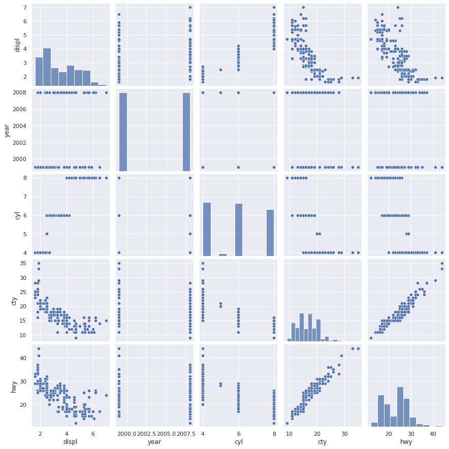

```python
sns.pairplot(mpg)
```

As with other figure-level functions, the size of the figure is controlled by setting the height of each individual subplot:

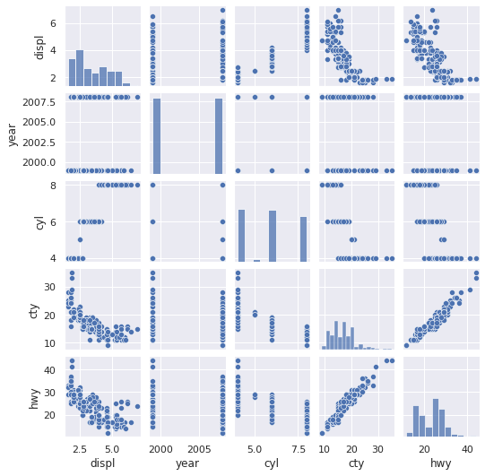

```python
sns.pairplot(mpg, height=1.5)
```

**RQ10: What are the associations between numerical variables in the data by two different year? What are the distributions of them?**

In addition the previous example, we will include the third variable, year. Remember that we use `hue`argument to add the third variable.

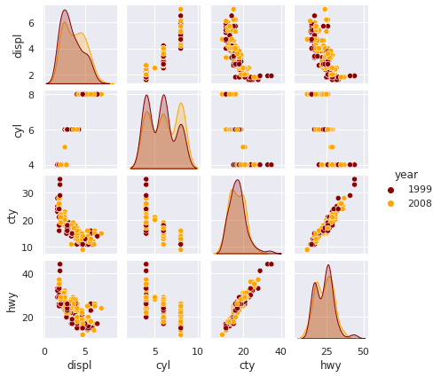

```python
sns.pairplot(mpg, height=1.5, hue = 'year' , palette = ['darkred','orange'])
```

If you draw a subplot from this matrix, you can use `jointplot` command.

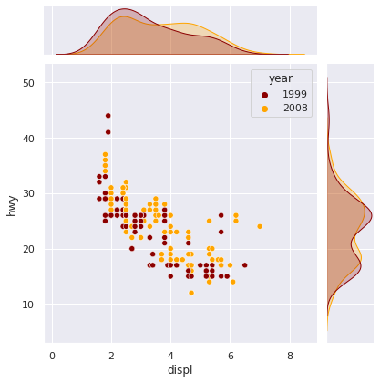

```python
sns.jointplot(data=mpg,x="displ",y="hwy",hue="year", palette = ['darkred','orange'])
```

[figure not shown]

## **Exercise 1**

Consider `flights.xlsx` data. The data description given below.

Description: On-time data for all flights that departed NYC (i.e. JFK, LGA or EWR) in 1-1-2013.

year, month, day : Date of departure.

dep_time, arr_time : Actual departure and arrival times (format HHMM or HMM), local tz.

sched_dep_time, sched_arr_time : Scheduled departure and arrival times (format HHMM or HMM), local tz.

dep_delay, arr_delay: Departure and arrival delays, in minutes. Negative times represent early departures/arrivals.

carrier: Two letter carrier abbreviation. See airlines to get name.

flight: Flight number.

tailnum: Plane tail number. See planes for additional metadata.

origin, dest: Origin and destination. See airports for additional metadata.

air_time: Amount of time spent in the air, in minutes.

distance: Distance between airports, in miles.

hour, minute : Time of scheduled departure broken into hour and minutes.

time_hour : Scheduled date and hour of the flight as a POSIXct date. Along with origin, can be used to join flights data to weather data.

temp, dewp : Temperature and dewpoint in F.

humid : Relative humidity.

wind_dir, wind_speed, wind_gust : Wind direction (in degrees), speed and gust speed (in mph).

precip : Precipitation, in inches.

pressure : Sea level pressure in millibars.

visib : Visibility in miles.

time_hour : Date and hour of the recording as a POSIXct date.

Import the data.

```python
flight = pd.read_excel('flights.xlsx')
flight.head()
```

|  | year | month | day | dep_time | sched_dep_time | dep_delay | arr_time | sched_arr_time | arr_delay | carrier | ... | time_hour | temp | dewp | humid | wind_dir | wind_speed | wind_gust | precip | pressure | visib |
| --- | --- | --- | --- | --- | --- | --- | --- | --- | --- | --- | --- | --- | --- | --- | --- | --- | --- | --- | --- | --- | --- |
| 0 | 2013 | 1 | 1 | 517 | 515 | 2 | 830 | 819 | 11 | UA | ... | 2013-01-01 05:00:00 | 39.02 | 28.04 | 64.43 | 260 | 12.65858 | NaN | 0 | 1011.9 | 10 |
| 1 | 2013 | 1 | 1 | 517 | 515 | 2 | 830 | 819 | 11 | UA | ... | 2013-01-01 05:00:00 | 39.02 | 26.96 | 61.63 | 260 | 14.96014 | NaN | 0 | 1012.1 | 10 |
| 2 | 2013 | 1 | 1 | 517 | 515 | 2 | 830 | 819 | 11 | UA | ... | 2013-01-01 05:00:00 | 39.92 | 24.98 | 54.81 | 250 | 14.96014 | 21.86482 | 0 | 1011.4 | 10 |
| 3 | 2013 | 1 | 1 | 533 | 529 | 4 | 850 | 830 | 20 | UA | ... | 2013-01-01 05:00:00 | 39.02 | 28.04 | 64.43 | 260 | 12.65858 | NaN | 0 | 1011.9 | 10 |
| 4 | 2013 | 1 | 1 | 533 | 529 | 4 | 850 | 830 | 20 | UA | ... | 2013-01-01 05:00:00 | 39.02 | 26.96 | 61.63 | 260 | 14.96014 | NaN | 0 | 1012.1 | 10 |

5 rows × 28 columns

Please use the seaborn functions to answer the following questions.

**1. What is the distribution of the departure time (dep_time)?**

**2. What is the frequency distribution of the origin?**

**3. What is the association between departure time and arrival time?**

**4. What are the top 10 destination points and the corresponding number of destination?**

**5. What is the relationship between departure time and arrival time by origin?**

**6. How does the departure time change by hour?**

**7.How does the temperature change by the time?**

**8. Which pairs of the variables are the most correlated ones in the data?**

**9. What is the distribution of the departure time in each origin by hour?**

**10. What is the relationship between distance and air_time in each origin?**

**11. Draw the scatter plot matrix of the numerical variables in the data**

#### **Thank you for this great semester, good luck with your finals and projects!**

[figure not shown]

**Suggessted Sources for Seaborn**

- [Python Graph Gallery](https://www.python-graph-gallery.com/)
- [Customizing Seaborn Plots](https://colab.research.google.com/github/goodboychan/chans_jupyter/blob/main/_notebooks/2020-06-27-01-Customizing-Seaborn-Plots.ipynb#scrollTo=08jmpJH14WUl)
- [Seaborn Examples with codes](https://seaborn.pydata.org/examples/index.html)